# PCA

Pablo, Eva

22/5/2020

# Principal Component Analysis

Primero cargamos los datos Motor Trend Car Road Tests *mtcars* .

```r
str(mtcars)
```

```
## 'data.frame':    32 obs. of  11 variables:
##  $ mpg : num  21 21 22.8 21.4 18.7 18.1 14.3 24.4 22.8 19.2 ...
##  $ cyl : num  6 6 4 6 8 6 8 4 4 6 ...
##  $ disp: num  160 160 108 258 360 ...
##  $ hp  : num  110 110 93 110 175 105 245 62 95 123 ...
##  $ drat: num  3.9 3.9 3.85 3.08 3.15 2.76 3.21 3.69 3.92 3.92 ...
##  $ wt  : num  2.62 2.88 2.32 3.21 3.44 ...
##  $ qsec: num  16.5 17 18.6 19.4 17 ...
##  $ vs  : num  0 0 1 1 0 1 0 1 1 1 ...
##  $ am  : num  1 1 1 0 0 0 0 0 0 0 ...
##  $ gear: num  4 4 4 3 3 3 3 4 4 4 ...
##  $ carb: num  4 4 1 1 2 1 4 2 2 4 ...
```

Tenemos 32 observaciones con 11 variables numericas.Para calcular los componentes principales, usaremos la matriz de correlación dado que las unidades de nuestras variables son distintas.

Para eso scamos la matriz de correlacion $R$ que es la siguiente.

```r
(R <- round(cor(mtcars),3))
```

```
##         mpg    cyl   disp     hp   drat     wt   qsec     vs     am   gear
## mpg   1.000 -0.852 -0.848 -0.776  0.681 -0.868  0.419  0.664  0.600  0.480
## cyl  -0.852  1.000  0.902  0.832 -0.700  0.782 -0.591 -0.811 -0.523 -0.493
## disp -0.848  0.902  1.000  0.791 -0.710  0.888 -0.434 -0.710 -0.591 -0.556
## hp   -0.776  0.832  0.791  1.000 -0.449  0.659 -0.708 -0.723 -0.243 -0.126
## drat  0.681 -0.700 -0.710 -0.449  1.000 -0.712  0.091  0.440  0.713  0.700
## wt   -0.868  0.782  0.888  0.659 -0.712  1.000 -0.175 -0.555 -0.692 -0.583
## qsec  0.419 -0.591 -0.434 -0.708  0.091 -0.175  1.000  0.745 -0.230 -0.213
## vs    0.664 -0.811 -0.710 -0.723  0.440 -0.555  0.745  1.000  0.168  0.206
## am    0.600 -0.523 -0.591 -0.243  0.713 -0.692 -0.230  0.168  1.000  0.794
## gear  0.480 -0.493 -0.556 -0.126  0.700 -0.583 -0.213  0.206  0.794  1.000
## carb -0.551  0.527  0.395  0.750 -0.091  0.428 -0.656 -0.570  0.058  0.274
##        carb
## mpg  -0.551
## cyl   0.527
## disp  0.395
## hp    0.750
## drat -0.091
## wt    0.428
## qsec -0.656
## vs   -0.570
## am    0.058
## gear  0.274
## carb  1.000
```

Ahora para calcular las componentes principales encontraremos sus egienvecores.

```r
eig <- eigen(R)
(y <- round(eig$vectors,3))
```

```
##         [,1]   [,2]   [,3]   [,4]   [,5]   [,6]   [,7]   [,8]   [,9]
##  [1,]  0.363 -0.016 -0.226 -0.024 -0.102  0.107  0.344  0.762  0.243
##  [2,] -0.374 -0.044 -0.176 -0.004 -0.055 -0.171  0.052  0.233  0.059
##  [3,] -0.368  0.049 -0.061  0.259 -0.397  0.330  0.216  0.005  0.199
##  [4,] -0.330 -0.249  0.140 -0.069 -0.540 -0.074 -0.009  0.229 -0.574
##  [5,]  0.294 -0.275  0.161  0.854 -0.074 -0.250  0.022 -0.028 -0.048
##  [6,] -0.346  0.143  0.342  0.249  0.073  0.465 -0.016  0.004  0.357
##  [7,]  0.200  0.463  0.403  0.068  0.163  0.329  0.045  0.240 -0.525
##  [8,]  0.307  0.232  0.429 -0.214 -0.598 -0.195 -0.265 -0.038  0.360
##  [9,]  0.235 -0.430 -0.205 -0.027 -0.094  0.574 -0.584  0.041 -0.046
## [10,]  0.207 -0.462  0.290 -0.263 -0.050  0.239  0.618 -0.317 -0.005
## [11,] -0.214 -0.414  0.528 -0.129  0.362 -0.179 -0.190  0.387  0.176
##        [,10]  [,11]
##  [1,]  0.143 -0.124
##  [2,] -0.844 -0.149
##  [3,]  0.043  0.661
##  [4,]  0.248 -0.254
##  [5,] -0.101 -0.040
##  [6,]  0.099 -0.567
##  [7,] -0.274  0.181
##  [8,] -0.160  0.005
##  [9,] -0.182  0.027
## [10,] -0.213 -0.053
## [11,]  0.071  0.320
```

### Graficas y Analisis

Haremos la grafica de codo correspondiente, para dererminar cuales son las componentes mas significativas. Para realizar esto, veremos que tanta varianza aporta cada componente principal, mediante el siguiente razonamiento.

$$\frac{\lambda_{k}}{p}$$

Donde $\lambda_k$ es la k-esima componente principal y p es la suma de la diagonal de la matriz de covarianza $R$.

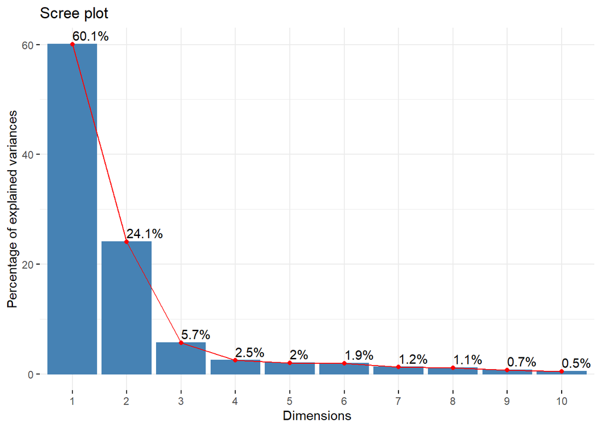

```r
fviz_screeplot(z,barfill = "steelblue",barcolor = "steelblue",linecolor = "red",addlabels =TRUE)
```

Observamos que con los primeros dos componentes principales acumulamos un $84\%$ de variabilidad de la muestra por lo tanto podemos hacer un alaisis con estos dos.

Veremos que tanto contribuyen y a que dimension las variables de nuestro dataset.

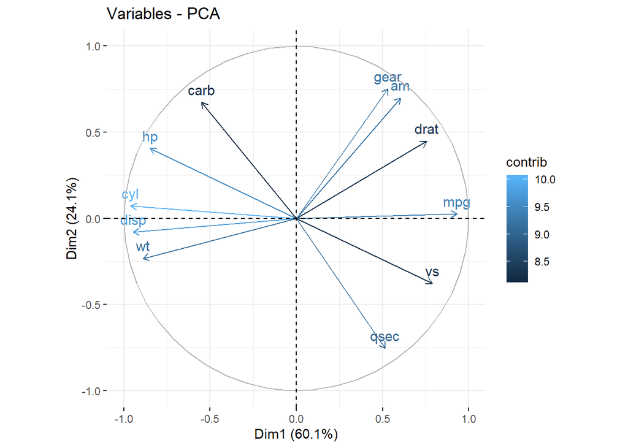

```r
fviz_pca_var(z,col.var="contrib")
```

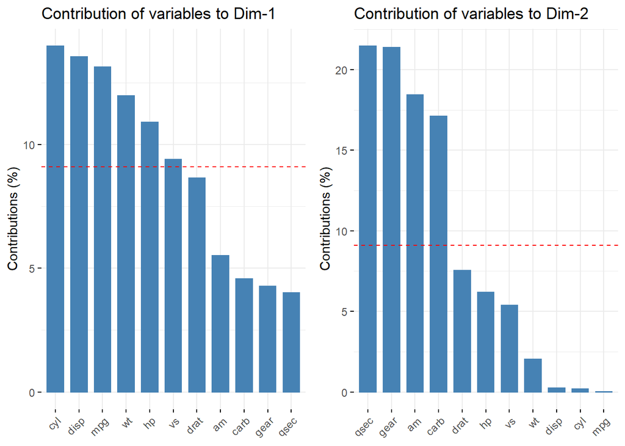

```r
gr1 <- fviz_contrib(z,choice = "var", axes = 1)
gr2 <- fviz_contrib(z,choice = "var", axes = 2)
grid.arrange(gr1, gr2, ncol = 2)
```

Ahora podemos ver el comportamiento en dos dimensiones de nuestros datos a partir de los primeros dos componentes prinicpales.

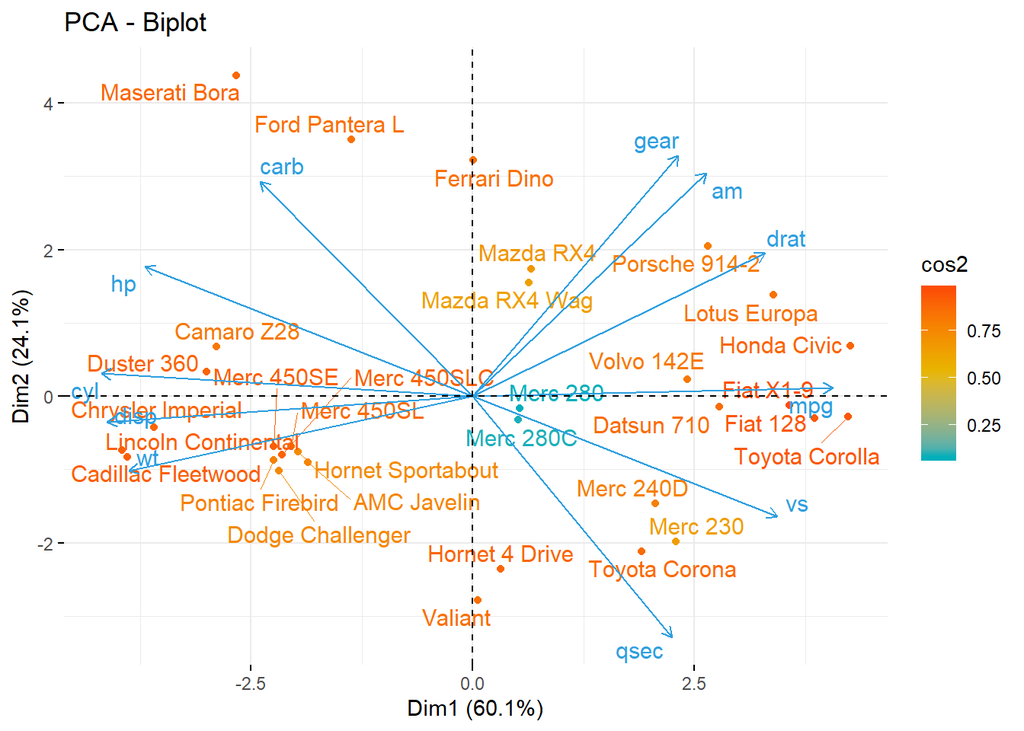

```r
fviz_pca_biplot(z,
                col.var = "#2E9FDF", # Variables color
                col.ind = "cos2", # Color by the quality of representation
                gradient.cols = c("#00AFBB", "#E7B800", "#FC4E07"),
                repel = TRUE
                )
```

Podemos ver que del lado derecho de la grafica en su mayoria son automoviles que no provienen de marcas estdounidenses y que su consumo en gasolina es menor. Por el otro lado del lado izquierdo apuntan a automoviles con mayor uso de combustible y en su mayoria de marcas estadounidenses. En la parte superior podemos ver autos deportivos y en su mayoria europeos.